# Seminar Homework

Rishabh

Thursday, January 29, 2015

### 1. Wrapper Functions

The idea is to encapsulate frequently used segments of codes into logical functions. Most of these are taken from the sample codes provided in the first seminar

```r
#Wrapper functions

#Create variance covariance matrix
sigmaXY <- function(rho, sdX, sdY) {
  covTerm <- rho * sdX * sdY
  VCmatrix <- matrix(c(sdX^2, covTerm, covTerm, sdY^2),
                     2, 2, byrow = TRUE)
  return(VCmatrix)
}

#Create a BI Variate NOrmal distribution
genBVN <- function(n = 1, seed = NA, muXY=c(0,1), sigmaXY=diag(2)) {
  if(!is.na(seed)) set.seed(seed)
  rdraws <- rmvnorm(n, mean = muXY, sigma = sigmaXY)
  return(rdraws)
}

#Create a dataset for classification
animals <- function(rho, sdXY, muXY, noSim, seed = 5341) {
  catsVC     <- sigmaXY(rho[1], sdXY[[1]][1], sdXY[[1]][2])
  dogsVC     <- sigmaXY(rho[2], sdXY[[2]][1], sdXY[[2]][2])
  maggotsVC    <- sigmaXY(rho[3], sdXY[[3]][1], sdXY[[3]][2])

  catsBVN    <- genBVN(noSim[1], seed = 5341, muXY[[1]], catsVC)
  dogsBVN    <- genBVN(noSim[2], seed = 5342, muXY[[2]], dogsVC)
  maggotsBVN <- genBVN(noSim[3], seed = 5343, muXY[[3]], maggotsVC)

  animalsDf <- as.data.frame(rbind(catsBVN,dogsBVN, maggotsBVN))
  Animal <- c(rep("Cats", noSim[1]), rep("Dogs", noSim[2]), rep("Maggots", noSim[3]))
  animalsDf <- cbind(animalsDf, Animal)
  colnames(animalsDf) <- c("weight", "height", "Animal")

  #Provide 1 0 labels to relevant class
  animalsDf <- cbind(animalsDf, labCats = c(rep(1, noAnimals[1]), rep(0, noAnimals[2]), rep(0, noAnimals[3])))
  animalsDf <- cbind(animalsDf, labDogs = c(rep(0, noAnimals[1]), rep(1, noAnimals[2]), rep(0, noAnimals[3])))
  animalsDf <- cbind(animalsDf, labMaggots = c(rep(0, noAnimals[1]), rep(0, noAnimals[2]), rep(1, noAnimals[3])))

  return(animalsDf)
}

#maps numerical categories to character labels
numToChar <- function(x) { if(which.max(x) ==1) {return ("Cats")}
                                                else if (which.max(x) == 2){ return ("Dogs")}
                                                else {return ("Maggots")}}


#
plotAnimals <- function() {
    p <- ggplot(data = animalsDF, aes(x = height, y = weight,
           colour=Animal, fill=Animal)) +
    geom_point() +
    xlab("Height") +
    ylab("Weight") +
    theme_bw(base_size = 14, base_family = "Helvetica") +
    scale_color_manual("Animal",
       values = c("Boundary" = "grey", "Cats" = "blue", "Dogs" = "red", "Maggots" = "Orange"))

    p
}
```

### 2. This sections deals with simulating heights and weights of 3 animal types.

The animals are cats dogs and maggots. We also display these simulations graphically

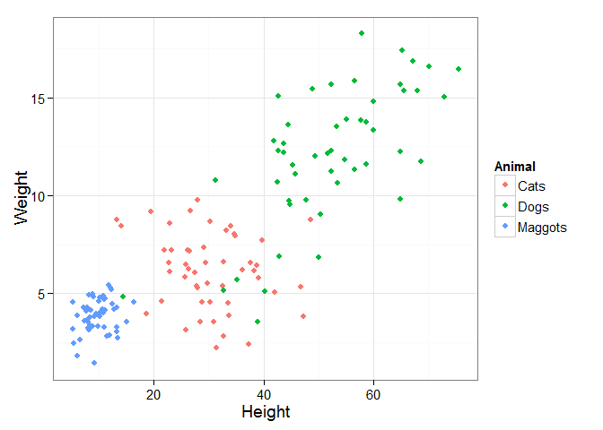

```r
#Simulate three variables for categories Cats Dogs and Maggots
noAnimals <- c(50, 50, 50)
rho  <- c(-0.2, 0.8, 0.02)
sdXY <- list(c(2, 8), c(3.5, 12), c(1, 3))
muXY <- list(c(6, 30), c(12, 50), c(4,10))

animalsDF <- animals(rho, sdXY, muXY, noAnimals)

# illustrating the data
ggplot(data = animalsDF, aes(x = height, y = weight,
       colour=Animal, fill=Animal)) +
geom_point() +
xlab("Height") +
ylab("Weight") +
theme_bw(base_size = 14, base_family = "Helvetica")
```

### 3. K = 3 class classification

1.We construct K classifiers corresponding to K classes and predict the type of animal

```r
areYouACat <- lm(labCats ~ weight + height, data = animalsDF)
areYouADog <- lm(labDogs ~ weight + height, data = animalsDF)
areYouAMaggot <- lm(labMaggots ~ weight + height, data = animalsDF)

predict <- cbind(predict(areYouACat), predict(areYouADog), predict(areYouAMaggot))
predictLabel <- apply(predict, 1, numToChar)
```

### 4. Results and interpretation

The table below shows that our classifier works well for Dogs and Maggots but performs very badly for Cats. This is a known issue of using linear regression classification. When K >= 3 masking of classes may occur.

```r
table(animalsDF$Animal, predictLabel)
```

```
##          predictLabel
##           Cats Dogs Maggots
##   Cats      24    7      19
##   Dogs       6   43       1
##   Maggots    0    0      50
```

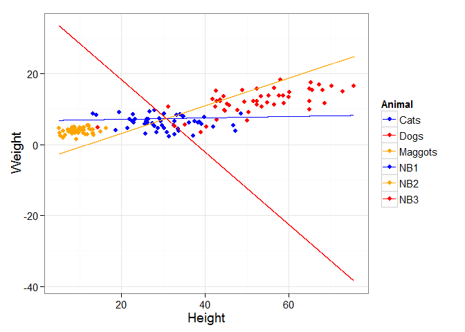

```r
wCat <- coef(areYouACat)
wDog <- coef(areYouADog)
wMag <- coef(areYouAMaggot)


x <- seq(min(animalsDF$height), max(animalsDF$height), 0.01)
y1 <- -((wCat[3] - wDog[3]) / (wCat[2] - wDog[2])) * x + ((wDog[1] - wCat[1]) / (wCat[2] - wDog[2]))
y2 <- -((wMag[3] - wCat[3]) / (wMag[2] - wCat[2])) * x + ((wCat[1] - wMag[1]) / (wMag[2] - wCat[2]))
y3 <- -((wDog[3] - wMag[3]) / (wDog[2] - wMag[2])) * x + ((wMag[1] - wDog[1]) / (wDog[2] - wMag[2]))


boundDF1 <- data.frame(height = x , weight = y1, Animal=rep("NB1", length(x)))
boundDF2 <- data.frame(height = x , weight = y2, Animal=rep("NB2", length(x)))
boundDF3 <- data.frame(height = x , weight = y3, Animal=rep("NB3", length(x)))

plotAnimals() +
  geom_line(data = boundDF1) +
  geom_line(data = boundDF2) +
  geom_line(data = boundDF3) +
  scale_color_manual("Animal",
   values = c("NB1" = "blue", "Boundary" = "grey",
              "Cats" = "blue", "Dogs" = "red", "Maggots" = "orange",
              "NB2" = "Orange", "NB3" = "Red"))
```

This translates to three sets of equations. Example of boundary between dogs and cats is with the following structure:

$weight=-\frac{w_{cat,height}-w_{dog,height}}{w_{cat,weight}-w_{dog,weight}}\: height\:+\frac{w_{dog,bias}-w_{cat,bias}}{w_{cat,weight}-w_{dog,weight}}$

We will have another two equations which will divide our space into singly connected convex hyperplanes.

$w_{weight} x_{weight} + w_{height} x_{height} + w_0 = (code_{weight} + code_{height})/2$